# Getting Started with NNS: Comparing Distributions

Fred Viole

```r
library(NNS)
require(knitr)
require(rgl)
```

# Comparing Distributions

**`NNS`** offers a multitude of ways to test if distributions came from the same population, or if they share the same mean or median. The underlying function for these tests is **`NNS.ANOVA()`**.

The output from **`NNS.ANOVA()`** includes a descriptive `Certainty` statistic. `means.only = TRUE` compares group means through their directional area balance, `means.only = FALSE` compares profiles over shared quantiles, and `medians = TRUE` compares median targets. Agreement in one mode does not establish equality for the other targets. The finite-sample adjustment can make the maximum less than one. Certainty is not a calibrated p-value or power; inferential calibration must match the target and sampling design.

## Test if Same Population

Below we run the analysis to whether automatic transmissions and manual transmissions have significantly different `mpg` distributions per the `mtcars` dataset.

The plot on the left shows the resampling distribution of `Certainty`. Its inferential interpretation requires the resampling scheme to match the target; pooled permutation calibrates equal distributions under exchangeability, not every equal-means null with unequal variances. The plot on the right illustrates the control and treatment variables, along with the grand mean among variables, and the confidence interval associated with the control mean.

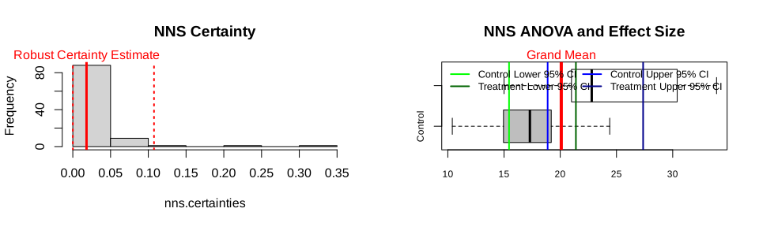

```
## $Control
## [1] 17.14737
##
## $Treatment
## [1] 24.39231
##
## $Grand_Statistic
## [1] 20.09063
##
## $Control_CDF
## [1] 0.8708501
##
## $Treatment_CDF
## [1] 0.1294878
##
## $Certainty
## [1] 0.02345583
##
## $`Effect_Size_LB.2.5%`
## [1] 2.512389
##
## $`Effect_Size_UB.97.5%`
## [1] 11.92337
##
## $Confidence_Level
## [1] 0.95
##
## $`Robust Certainty Estimate`
## [1] 0.01817245
##
## $`Lower 95% CI`
## [1] 0.0001057568
##
## $`Upper 95% CI`
## [1] 0.1075709
```

```r
mpg_auto_trans = mtcars[mtcars$am==1, "mpg"]
mpg_man_trans = mtcars[mtcars$am==0, "mpg"]

NNS.ANOVA(control = mpg_man_trans, treatment = mpg_auto_trans, robust = TRUE)
```

The `Certainty` describes disagreement for the selected target. The Mann-Whitney-Wilcoxon result below addresses a rank-based hypothesis under its own assumptions; it is not a universal test of all distributional differences or a calibration of NNS certainty.

```r
wilcox.test(mpg ~ am, data=mtcars)
```

```
##
##  Wilcoxon rank sum test with continuity correction
##
## data:  mpg by am
## W = 42, p-value = 0.001871
## alternative hypothesis: true location shift is not equal to 0
```

## Test if means are Equal

Here we provide the output from **`NNS.ANOVA()`** and `t.test()` functions on two Normal distribution samples, where we are pretty certain these two means are equal.

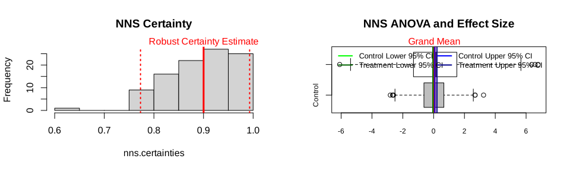

```
## $Control
## [1] 0.01612787
##
## $Treatment
## [1] 0.08493051
##
## $Grand_Statistic
## [1] 0.05052919
##
## $Control_CDF
## [1] 0.5218858
##
## $Treatment_CDF
## [1] 0.4893919
##
## $Certainty
## [1] 0.912545
##
## $`Effect_Size_LB.2.5%`
## [1] -0.1226692
##
## $`Effect_Size_UB.97.5%`
## [1] 0.2558928
##
## $Confidence_Level
## [1] 0.95
##
## $`Robust Certainty Estimate`
## [1] 0.9001731
##
## $`Lower 95% CI`
## [1] 0.7729845
##
## $`Upper 95% CI`
## [1] 0.9929432
```

```r
set.seed(123)
x = rnorm(1000, mean = 0, sd = 1)
y = rnorm(1000, mean = 0, sd = 2)

NNS.ANOVA(control = x, treatment = y,
          means.only = TRUE, robust = TRUE, plot = TRUE)
```

```r
t.test(x,y)
```

```
##
##  Welch Two Sample t-test
##
## data:  x and y
## t = -0.96711, df = 1454.4, p-value = 0.3336
## alternative hypothesis: true difference in means is not equal to 0
## 95 percent confidence interval:
##  -0.20835512  0.07074984
## sample estimates:
##  mean of x  mean of y
## 0.01612787 0.08493051
```

## Test if means are Unequal

By altering the mean of the `y` variable, we can start to see the sensitivity of the results from the two methods, where both firmly reject the null hypothesis of identical means.

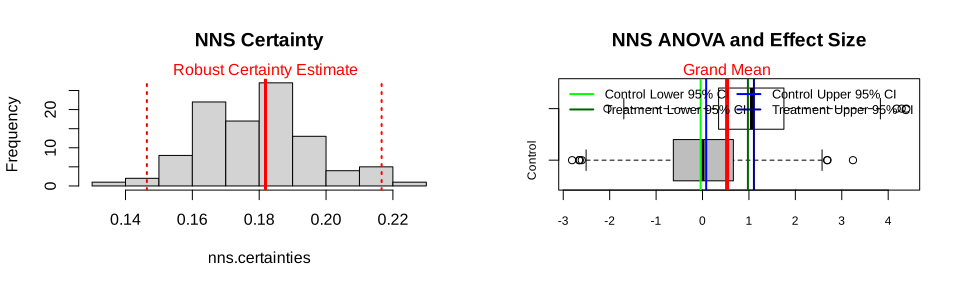

```
## $Control
## [1] 0.01612787
##
## $Treatment
## [1] 1.042465
##
## $Grand_Statistic
## [1] 0.5292966
##
## $Control_CDF
## [1] 0.7862176
##
## $Treatment_CDF
## [1] 0.2197938
##
## $Certainty
## [1] 0.1824463
##
## $`Effect_Size_LB.2.5%`
## [1] 0.8993267
##
## $`Effect_Size_UB.97.5%`
## [1] 1.14823
##
## $Confidence_Level
## [1] 0.95
##
## $`Robust Certainty Estimate`
## [1] 0.1818801
##
## $`Lower 95% CI`
## [1] 0.1463972
##
## $`Upper 95% CI`
## [1] 0.2166297
```

```r
set.seed(123)
x = rnorm(1000, mean = 0, sd = 1)
y = rnorm(1000, mean = 1, sd = 1)

NNS.ANOVA(control = x, treatment = y,
          means.only = TRUE, robust = TRUE, plot = TRUE)
```

```r
t.test(x,y)
```

```
##
##  Welch Two Sample t-test
##
## data:  x and y
## t = -22.933, df = 1997.4, p-value < 2.2e-16
## alternative hypothesis: true difference in means is not equal to 0
## 95 percent confidence interval:
##  -1.1141064 -0.9385684
## sample estimates:
##  mean of x  mean of y
## 0.01612787 1.04246525
```

The effect size from **`NNS.ANOVA()`** is calculated from the confidence interval of the control mean and the specified `y` shift of 1 is within the provided lower and upper effect boundaries.

## Medians

In order to test medians instead of means, simply set both `means.only = TRUE` and `medians = TRUE` in **`NNS.ANOVA()`**.

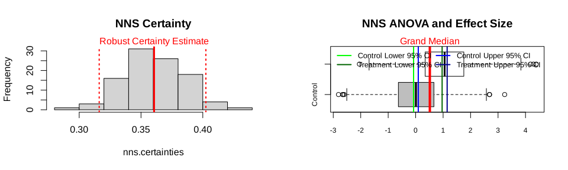

```
## $Control
## [1] 0.009209639
##
## $Treatment
## [1] 1.054852
##
## $Grand_Statistic
## [1] 0.5162715
##
## $Control_CDF
## [1] 0.7
##
## $Treatment_CDF
## [1] 0.3
##
## $Certainty
## [1] 0.3592804
##
## $`Effect_Size_LB.2.5%`
## [1] 0.8684753
##
## $`Effect_Size_UB.97.5%`
## [1] 1.222264
##
## $Confidence_Level
## [1] 0.95
##
## $`Robust Certainty Estimate`
## [1] 0.3605887
##
## $`Lower 95% CI`
## [1] 0.3161758
##
## $`Upper 95% CI`
## [1] 0.4024833
```

```r
NNS.ANOVA(control = x, treatment = y,
          means.only = TRUE, medians = TRUE, robust = TRUE, plot = TRUE)
```

# Stochastic Superiority

Stochastic superiority asks a different question than equality of means or equality of distributions. Rather than testing whether two samples came from the same population, or whether they share the same mean or median, stochastic superiority measures the probability that a random draw from one distribution exceeds a random draw from another.

For two random variables $X$ and $Y$, the stochastic superiority probability is:

$$P(X > Y)$$

and with ties accounted for, the tie-adjusted stochastic superiority measure is:

$$P^* = P(X > Y) + \frac{1}{2} P(X = Y)$$

A value of $P^* = 0.5$ indicates no directional advantage, values above $0.5$ favor $X$, and values below $0.5$ favor $Y$.

This differs from stochastic dominance. Stochastic superiority is a pairwise exceedance probability, while stochastic dominance requires one distribution to be preferred to another over the entire shared support.

Below is an example using the same data generating process from the unequal means example.

```r
set.seed(123)
x = rnorm(1000, mean = 0, sd = 1)
y = rnorm(1000, mean = 1, sd = 1)

NNS.SS(x, y)
```

```
## $p_gt
## [1] 0.233915
##
## $p_tie
## [1] 0
##
## $p_star
## [1] 0.233915
```

Since $y$ was generated with a higher mean, the stochastic superiority probability for $x$ relative to $y$ should be less than $0.5$, indicating that a draw from $x$ is less likely to exceed a draw from $y$.

We can also obtain confidence intervals for the tie-adjusted superiority probability using maximum entropy bootstrap replicates.

```r
NNS.SS(x, y, confidence.interval = TRUE, reps = 999, ci = 0.95)[1:5]

$p_gt
[1] 0.233915

$p_tie
[1] 0

$p_star
[1] 0.233915

$lower
[1] 0.2105631

$upper
[1] 0.2537789
```

This provides an interpretable effect size for directional comparison between two distributions without requiring identical distributions or equal variances.

For discrete variables, ties may occur with positive probability, and the reported `p_tie` and `p_star` values reflect that adjustment explicitly.

```r
set.seed(123)
x = sample(1:5, 100, replace = TRUE)
y = sample(1:5, 100, replace = TRUE)

NNS.SS(x, y)
```

```
## $p_gt
## [1] 0.3982
##
## $p_tie
## [1] 0.1992
##
## $p_star
## [1] 0.4978
```

# Stochastic Dominance

Another method of comparing distributions involves a test for stochastic dominance. The first, second, and third degree stochastic dominance tests are available in **`NNS`** via:

- **`NNS.FSD()`**
- **`NNS.SSD()`**
- **`NNS.TSD()`**

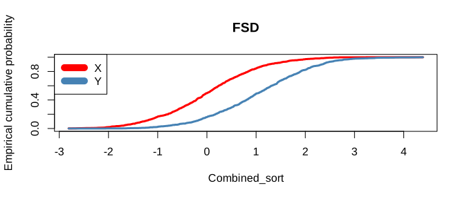

```
## [1] "Y FSD X"
```

```r
set.seed(123)
x = rnorm(1000, mean = 0, sd = 1)
y = rnorm(1000, mean = 1, sd = 1)

NNS.FSD(x, y)
```

**`NNS.FSD()`** correctly identifies the shift in the `y` variable we specified when testing for unequal means.

## Stochastic Dominant Efficient Sets

**`NNS`** also offers the ability to isolate a set of variables that do not have any dominated constituents with the **`NNS.SD.efficient.set()`** function.

`x2, x4, x6, x8` all dominate their preceding distributions yet do not dominate one another, and are thus included in the first degree stochastic dominance efficient set.

```r
set.seed(123)
x1 = rnorm(1000)
x2 = x1 + 1
x3 = rnorm(1000)
x4 = x3 + 1
x5 = rnorm(1000)
x6 = x5 + 1
x7 = rnorm(1000)
x8 = x7 + 1

NNS.SD.efficient.set(cbind(x1, x2, x3, x4, x5, x6, x7, x8), degree = 1, status = FALSE)
```

```
## [1] "x4" "x2" "x8" "x6"
```

## Stochastic Dominant Clusters

Further, we can assign clusters to non dominated constituents and represent the clustering in a dendrogram.

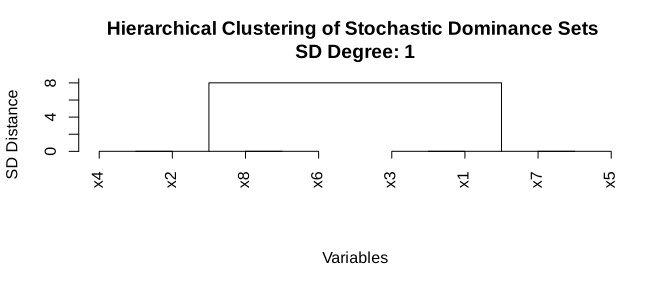

```
## $Clusters
## $Clusters$Cluster_1
## [1] "x4" "x2" "x8" "x6"
##
## $Clusters$Cluster_2
## [1] "x3" "x1" "x7" "x5"
##
##
## $Dendrogram
##
## Call:
## hclust(d = dist_matrix, method = "complete")
##
## Cluster method   : complete
## Number of objects: 8
```

```r
NNS.SD.cluster(cbind(x1, x2, x3, x4, x5, x6, x7, x8), degree = 1, dendrogram = TRUE)
```

# References

If the user is so motivated, detailed arguments and proofs are provided within the following:

- [Nonlinear Nonparametric Statistics: Using Partial Moments](https://ovvo-financial.github.io/NNS/book/)
- [Continuous CDFs and ANOVA with NNS](https://doi.org/10.2139/ssrn.3007373)
- [A Note on Stochastic Dominance](https://doi.org/10.2139/ssrn.3002675)
- [LPM Density Functions for the Computation of the SD Efficient Set](http://dx.doi.org/10.4236/jmf.2016.61012)